# developing a model of behavior

michael freund

2020-02-15

## a glance at the data

```r
stroop.pro <- stroop %>% filter(session == "pro", is.analysis.group)
stroop.pro.rt <- stroop.pro %>% filter(acc == 1, !is.na(rt), rt > 0)
stroop.pro.er <- stroop.pro %>% filter(!is.na(acc))
```

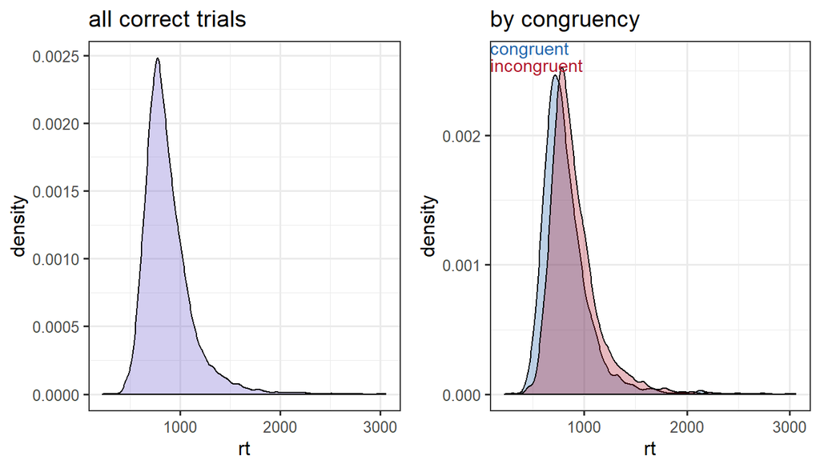

```r
grid.arrange(
  stroop.pro.rt %>%
    ggplot(aes(rt)) +
    geom_density(fill = "slateblue", alpha = 0.3) +
    labs(title = "all correct trials") +
    theme(legend.position = "none"),
  stroop.pro.rt %>%
    ggplot(aes(rt)) +
    geom_density(aes(fill = trial.type), alpha = 0.3) +
    labs(title = "by congruency") +
    scale_fill_manual(values = color.congruency) +
    theme(legend.position = "none") +
    annotate(
      y = Inf, x = -Inf, geom = "text", label = "congruent", color = color.congruency["congr"],
      vjust = 1, hjust = 0
      ) +
    annotate(
        y = 0.0026, x = -Inf, geom = "text", label = "incongruent", color = color.congruency["incon"],
        vjust = 1, hjust = 0
        ),
  ncol = 2
)
```

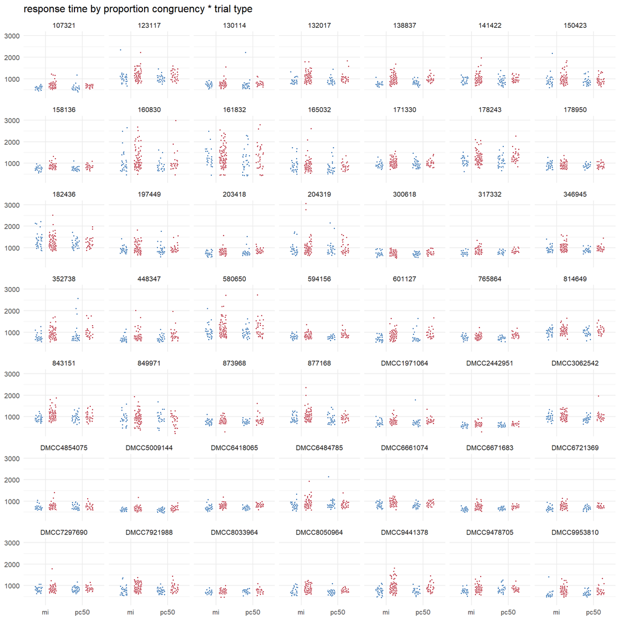

```r
stroop.pro.rt %>%
  ggplot(aes(pc, rt, fill = trial.type)) +
  geom_point(
    position = position_jitterdodge(jitter.width = 0.2),
    size = 0.5, shape = 21, color = "white"
    ) +
  facet_wrap(vars(subj)) +
  theme_minimal(base_size = 10) +
  theme(axis.title = element_blank(), legend.position = "none") +
  scale_fill_manual(values = color.congruency) +
  labs(title = "response time by proportion congruency * trial type")
```

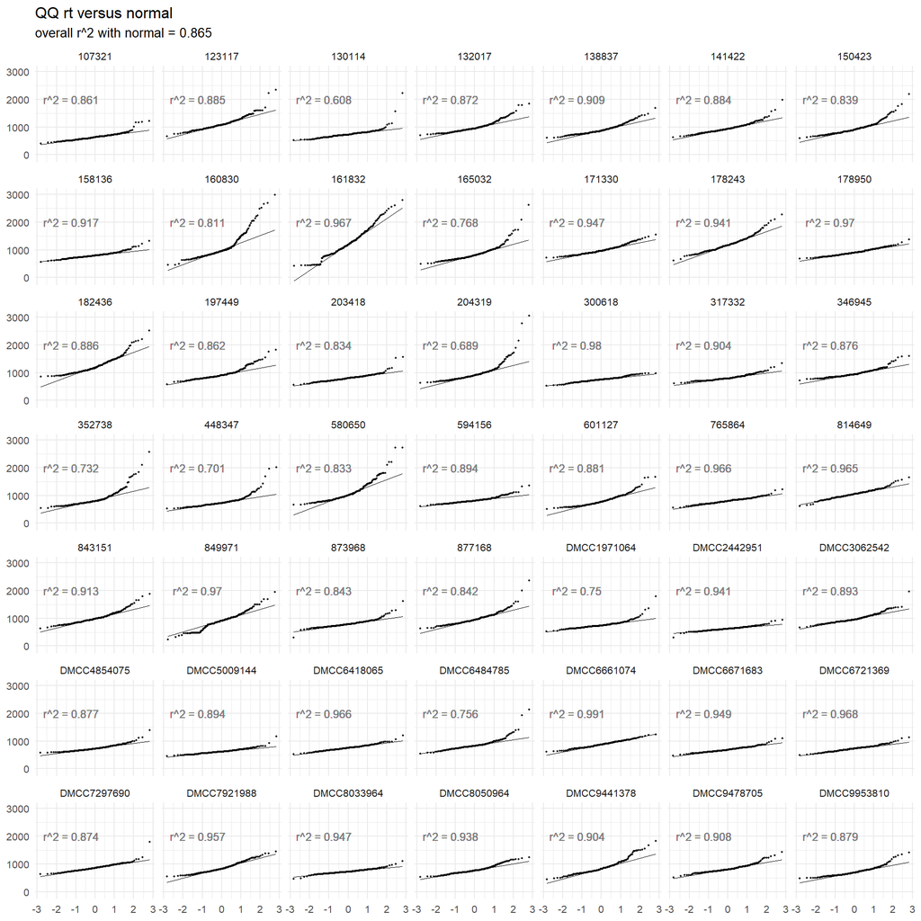

```r
stroop.pro.rt %>%
  full_join(group_by(., subj) %>% summarize(r2norm = qqr2(rt)), by = "subj") %>%
  ggplot(aes(sample = rt)) +
  stat_qq(alpha = 0.8, size = 0.4) +
  stat_qq_line(size = 0.25) +
  facet_wrap(vars(subj)) +
  geom_text(
    aes(
      x = -1.25, y = 2000,
      label = paste0("r^2 = ", round(r2norm, 3))
      ), size = 3, color = "grey50"
  ) +
  theme_minimal(base_size = 10) +
  theme(axis.title = element_blank()) +
  labs(
    title    = "QQ rt versus normal",
    subtitle = paste0("overall r^2 with normal = ", round(qqr2(stroop.pro$rt), 3))
  )
```

Looks like some problematically compressed (i.e., approx equal values) for a couple subjects: 849971 and 161832. This is seen as the kink in their QQ plots.

I’ll threshold these subjects’ data at $rt > 500$ to eliminate this issue. A total of 25 removed from 849971 and 16 for 161832.

```r
stroop.pro.rt <- stroop.pro.rt[!(stroop.pro.rt$subj %in% c("849971", "161832") & stroop.pro.rt$rt < 500), ]
```

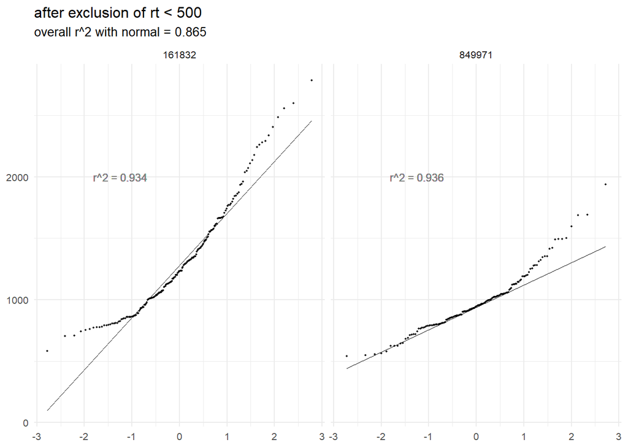

```r
stroop.pro.rt %>%
  filter(subj %in% c("849971", "161832")) %>%
  full_join(group_by(., subj) %>% summarize(r2norm = qqr2(rt)), by = "subj") %>%
  ggplot(aes(sample = rt)) +
  stat_qq(alpha = 0.8, size = 0.4) +
  stat_qq_line(size = 0.25) +
  facet_wrap(vars(subj)) +
  geom_text(
    aes(
      x = -1.25, y = 2000,
      label = paste0("r^2 = ", round(r2norm, 3))
      ), size = 3, color = "grey50"
  ) +
  theme_minimal(base_size = 10) +
  theme(axis.title = element_blank()) +
  labs(
    title    = "after exclusion of rt < 500",
    subtitle = paste0("overall r^2 with normal = ", round(qqr2(stroop.pro$rt), 3))
  )
```

### errors

[figure not shown]

```r
stroop.pro.er %>%
  transmute(error = mean(acc.final %in% c("0", "no.response"))) %>%
  ggplot(aes(x = subj, y = error)) +
  geom_col(position = position_dodge(width = 1.25), width = 0.75, color = "black") +
  scale_fill_brewer(type = "qual", palette = 1) +
  theme(
    axis.text.x = element_text(angle = 90, vjust = 0.5, hjust = 1),
    axis.ticks.x =  element_line(),
    legend.position = "none"
    ) +
  labs(title = "error rates")
```

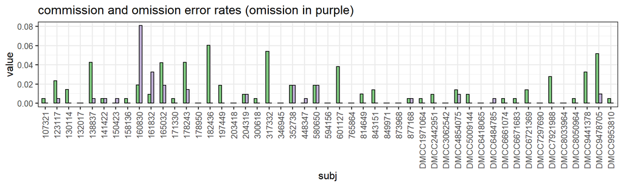

```r
stroop.pro.er %>%
  group_by(subj) %>%
    transmute(
    p.com = mean(acc.final == "0"),
    p.omi = mean(acc.final == "no.response")
  ) %>%
  reshape2::melt(id.vars = "subj") %>%
  ggplot(aes(x = subj, y = value, fill = variable)) +
  geom_col(position = position_dodge(width = 0.5), width = 0.5, color = "black") +
  scale_fill_brewer(type = "qual", palette = 1) +
  theme(
    axis.text.x = element_text(angle = 90, vjust = 0.5, hjust = 1),
    axis.ticks.x =  element_line(),
    legend.position = "none"
    ) +
  labs(title = "commission and omission error rates (omission in purple)")
```

160830 missed nearly 10/% of their trials (omitted response). This person may have been feeling drowsy. Will leave them in, though, but keep an eye on their estimates.

## model building

Set liberal bounds on RT, and count number of trials per subj * condition:

```r
stroop.pro.rt <- stroop.pro.rt %>% filter(rt < 3000, rt > 250)

counts.subj <- table(stroop.pro.rt$subj, stroop.pro.rt$trial.type) %>% as.data.frame
tidyr::spread(counts.subj, Var2, Freq) %>%
  rename(subj = Var1) %>%
  kable(digits = 2)
```

| subj | congr | incon |
| --- | --- | --- |
| 107321 | 67 | 139 |
| 123117 | 71 | 137 |
| 130114 | 71 | 139 |
| 132017 | 72 | 144 |
| 138837 | 72 | 131 |
| 141422 | 71 | 143 |
| 150423 | 71 | 143 |
| 158136 | 69 | 139 |
| 160830 | 59 | 122 |
| 161832 | 59 | 125 |
| 165032 | 68 | 133 |
| 171330 | 72 | 143 |
| 178243 | 70 | 130 |
| 178950 | 72 | 144 |
| 182436 | 72 | 131 |
| 197449 | 72 | 139 |
| 203418 | 72 | 144 |
| 204319 | 72 | 139 |
| 300618 | 72 | 143 |
| 317332 | 62 | 131 |
| 346945 | 72 | 143 |
| 352738 | 72 | 135 |
| 448347 | 72 | 143 |
| 580650 | 68 | 137 |
| 594156 | 72 | 144 |
| 601127 | 71 | 132 |
| 765864 | 72 | 144 |
| 814649 | 71 | 141 |
| 843151 | 72 | 141 |
| 849971 | 51 | 103 |
| 873968 | 72 | 144 |
| 877168 | 69 | 141 |
| DMCC1971064 | 72 | 143 |
| DMCC2442951 | 70 | 141 |
| DMCC3062542 | 72 | 144 |
| DMCC4854075 | 71 | 140 |
| DMCC5009144 | 72 | 142 |
| DMCC6418065 | 72 | 144 |
| DMCC6484785 | 72 | 143 |
| DMCC6661074 | 72 | 143 |
| DMCC6671683 | 72 | 143 |
| DMCC6721369 | 71 | 141 |
| DMCC7297690 | 72 | 144 |
| DMCC7921988 | 72 | 138 |
| DMCC8033964 | 71 | 144 |
| DMCC8050964 | 72 | 143 |
| DMCC9441378 | 72 | 137 |
| DMCC9478705 | 69 | 132 |
| DMCC9953810 | 72 | 143 |

### initial model comparison

```r
cl1 <- lmeControl(maxIter = 1e5, msMaxIter = 1e5, niterEM = 1e5, msMaxEval = 1e5)
cl2 <- lmeControl(maxIter = 1e5, msMaxIter = 1e5, niterEM = 1e5, msMaxEval = 1e5, opt = "nlm")

fit0 <- lme(rt ~ trial.type, stroop.pro.rt, ~ 1 | subj)
summary(fit0)
```

```
## Linear mixed-effects model fit by REML
##  Data: stroop.pro.rt
##      AIC    BIC logLik
##   136247 136276 -68120
##
## Random effects:
##  Formula: ~1 | subj
##         (Intercept) Residual
## StdDev:       153.4    186.8
##
## Fixed effects: rt ~ trial.type
##                 Value Std.Error    DF t-value p-value
## (Intercept)     827.1    22.142 10178   37.36       0
## trial.typeincon  81.9     3.911 10178   20.95       0
##  Correlation:
##                 (Intr)
## trial.typeincon -0.117
##
## Standardized Within-Group Residuals:
##     Min      Q1     Med      Q3     Max
## -3.5889 -0.5274 -0.1352  0.3193 10.0444
##
## Number of Observations: 10228
## Number of Groups: 49
```

```r
fit1.hom <- lme(rt ~ trial.type, stroop.pro.rt, ~ trial.type | subj)
summary(fit1.hom)
```

```
## Linear mixed-effects model fit by REML
##  Data: stroop.pro.rt
##      AIC    BIC logLik
##   136199 136242 -68093
##
## Random effects:
##  Formula: ~trial.type | subj
##  Structure: General positive-definite, Log-Cholesky parametrization
##                 StdDev Corr
## (Intercept)     153.21 (Intr)
## trial.typeincon  41.51 -0.085
## Residual        185.79
##
## Fixed effects: rt ~ trial.type
##                 Value Std.Error    DF t-value p-value
## (Intercept)     827.3    22.116 10178   37.41       0
## trial.typeincon  81.8     7.095 10178   11.52       0
##  Correlation:
##                 (Intr)
## trial.typeincon -0.135
##
## Standardized Within-Group Residuals:
##     Min      Q1     Med      Q3     Max
## -3.6333 -0.5218 -0.1340  0.3168 10.0191
##
## Number of Observations: 10228
## Number of Groups: 49
```

```r
fit1.het <- lme(
  rt ~ trial.type, stroop.pro.rt, ~ trial.type | subj,
  weights = varIdent(form = ∼ 1 | subj),
  control = cl1
  )
summary(fit1.het)
```

```
## Linear mixed-effects model fit by REML
##  Data: stroop.pro.rt
##      AIC    BIC logLik
##   132188 132579 -66040
##
## Random effects:
##  Formula: ~trial.type | subj
##  Structure: General positive-definite, Log-Cholesky parametrization
##                 StdDev Corr
## (Intercept)     150.07 (Intr)
## trial.typeincon  36.03 0.01
## Residual        110.88
##
## Variance function:
##  Structure: Different standard deviations per stratum
##  Formula: ~1 | subj
##  Parameter estimates:
##      107321      123117      130114      132017      138837      141422
##      1.0000      1.9626      1.3614      1.6362      1.4220      1.4877
##      150423      158136      160830      161832      165032      171330
##      1.9267      0.8944      3.9414      3.9666      2.4072      1.3604
##      178243      178950      182436      197449      203418      204319
##      2.2549      1.0427      2.5699      1.7306      1.0552      2.3967
##      300618      317332      346945      352738      448347      580650
##      0.7632      0.9239      1.2489      2.4306      1.7155      3.0107
##      594156      601127      765864      814649      843151      849971
##      0.9119      1.6979      0.8076      1.3682      1.7254      2.1531
##      873968      877168 DMCC1971064 DMCC2442951 DMCC3062542 DMCC4854075
##      1.1294      1.8893      1.1620      0.6325      1.4060      0.9750
## DMCC5009144 DMCC6418065 DMCC6484785 DMCC6661074 DMCC6671683 DMCC6721369
##      0.7300      0.7728      1.6407      1.0177      0.7499      0.7989
## DMCC7297690 DMCC7921988 DMCC8033964 DMCC8050964 DMCC9441378 DMCC9478705
##      1.1163      1.5469      0.7151      1.2216      1.9547      1.2266
## DMCC9953810
##      1.3067
## Fixed effects: rt ~ trial.type
##                 Value Std.Error    DF t-value p-value
## (Intercept)     826.7    21.641 10178   38.20       0
## trial.typeincon  81.3     6.183 10178   13.15       0
##  Correlation:
##                 (Intr)
## trial.typeincon -0.049
##
## Standardized Within-Group Residuals:
##     Min      Q1     Med      Q3     Max
## -4.8867 -0.6275 -0.1756  0.4246 10.0388
##
## Number of Observations: 10228
## Number of Groups: 49
```

```r
fit1.het1 <- lme(
  rt ~ trial.type, stroop.pro.rt, ~ trial.type | subj,
  weights = varIdent(form = ~ 1 | subj * trial.type),
  control = cl1
  )
summary(fit1.het1)
```

```
## Linear mixed-effects model fit by REML
##  Data: stroop.pro.rt
##      AIC    BIC logLik
##   132021 132766 -65908
##
## Random effects:
##  Formula: ~trial.type | subj
##  Structure: General positive-definite, Log-Cholesky parametrization
##                 StdDev Corr
## (Intercept)     149.45 (Intr)
## trial.typeincon  37.18 0.01
## Residual        112.64
##
## Variance function:
##  Structure: Different standard deviations per stratum
##  Formula: ~1 | subj * trial.type
##  Parameter estimates:
##      107321*incon      107321*congr      123117*congr      123117*incon
##            1.0000            0.9510            1.8625            1.9666
##      130114*incon      130114*congr      132017*incon      132017*congr
##            1.0282            1.8023            1.7838            1.1864
##      138837*incon      138837*congr      141422*incon      141422*congr
##            1.6278            0.8293            1.5388            1.3014
##      150423*incon      150423*congr      158136*congr      158136*incon
##            1.8442            1.9984            0.8178            0.9097
##      160830*incon      160830*congr      161832*congr      161832*incon
##            3.9455            3.7400            3.6447            4.0210
##      165032*congr      165032*incon      171330*incon      171330*congr
##            2.5038            2.2985            1.3769            1.2608
##      178243*congr      178243*incon      178950*incon      178950*congr
##            1.9105            2.3685            1.0023            1.0734
##      182436*incon      182436*congr      197449*congr      197449*incon
##            2.3943            2.7683            1.5697            1.7688
##      203418*incon      203418*congr      204319*incon      204319*congr
##            0.9619            1.1782            2.2999            2.4707
##      300618*congr      300618*incon      317332*incon      317332*congr
##            0.7588            0.7474            0.9934            0.6980
##      346945*incon      346945*congr      352738*congr      352738*incon
##            1.3141            1.0398            2.8582            2.1026
##      448347*incon      448347*congr      580650*congr      580650*incon
```

[output cut: 26 more lines]

```
##            1.3466            1.1556
## Fixed effects: rt ~ trial.type
##                 Value Std.Error    DF t-value p-value
## (Intercept)     824.9    21.533 10178   38.31       0
## trial.typeincon  82.5     6.282 10178   13.13       0
##  Correlation:
##                 (Intr)
## trial.typeincon -0.043
##
## Standardized Within-Group Residuals:
##     Min      Q1     Med      Q3     Max
## -4.7127 -0.6276 -0.1718  0.4376  7.4837
##
## Number of Observations: 10228
## Number of Groups: 49
```

```r
fit0.het1 <- lme(
  rt ~ trial.type, stroop.pro.rt, ~ 1 | subj,
  weights = varIdent(form = ~ 1 | subj * trial.type),
  control = cl1
  )
summary(fit0.het1)
```

```
## Linear mixed-effects model fit by REML
##  Data: stroop.pro.rt
##      AIC    BIC logLik
##   132100 132831 -65949
##
## Random effects:
##  Formula: ~1 | subj
##         (Intercept) Residual
## StdDev:         151    112.9
##
## Variance function:
##  Structure: Different standard deviations per stratum
##  Formula: ~1 | subj * trial.type
##  Parameter estimates:
##      107321*incon      107321*congr      123117*congr      123117*incon
##            1.0000            0.9595            1.8731            1.9689
##      130114*incon      130114*congr      132017*incon      132017*congr
##            1.0269            1.8121            1.8103            1.2193
##      138837*incon      138837*congr      141422*incon      141422*congr
##            1.7252            0.8704            1.5339            1.2947
##      150423*incon      150423*congr      158136*congr      158136*incon
##            1.8393            1.9891            0.8131            0.9068
##      160830*incon      160830*congr      161832*congr      161832*incon
##            3.9414            3.7381            3.6262            4.0122
##      165032*congr      165032*incon      171330*incon      171330*congr
##            2.5160            2.2972            1.3728            1.2543
##      178243*congr      178243*incon      178950*incon      178950*congr
##            1.9484            2.3928            1.0140            1.1584
##      182436*incon      182436*congr      197449*congr      197449*incon
##            2.3970            2.8234            1.5627            1.7635
##      203418*incon      203418*congr      204319*incon      204319*congr
##            0.9591            1.1709            2.2974            2.4785
##      300618*congr      300618*incon      317332*incon      317332*congr
##            0.7790            0.7510            0.9897            0.6941
##      346945*incon      346945*congr      352738*congr      352738*incon
##            1.3104            1.0355            2.8483            2.0975
##      448347*incon      448347*congr      580650*congr      580650*incon
##            1.8995            1.1714            2.2395            3.2651
##      594156*congr      594156*incon      601127*incon      601127*congr
##            0.7083            0.9737            1.7272            1.6087
```

[output cut: 23 more lines]

```
##            1.3518            1.1772
## Fixed effects: rt ~ trial.type
##                 Value Std.Error    DF t-value p-value
## (Intercept)     827.1    21.714 10178   38.09       0
## trial.typeincon  76.0     2.617 10178   29.03       0
##  Correlation:
##                 (Intr)
## trial.typeincon -0.074
##
## Standardized Within-Group Residuals:
##     Min      Q1     Med      Q3     Max
## -4.7799 -0.6295 -0.1640  0.4514  7.5354
##
## Number of Observations: 10228
## Number of Groups: 49
```

```r
afo <- anova(fit0, fit1.hom, fit1.het, fit1.het1, fit0.het1)

cbind(
  afo,
  BICweight = icweight(afo, "BIC"),
  AICweight = icweight(afo, "AIC")
  ) %>%
  kable(digits = 2)
```

|  | call | Model | df | AIC | BIC | logLik | Test | L.Ratio | p-value | BICweight | AICweight |
| --- | --- | --- | --- | --- | --- | --- | --- | --- | --- | --- | --- |
| fit0 | lme.formula(fixed = rt ~ trial.type, data = stroop.pro.rt, random = ~1 \| subj) | 1 | 4 | 136247 | 136276 | -68120 |  | NA | NA | 0 | 0 |
| fit1.hom | lme.formula(fixed = rt ~ trial.type, data = stroop.pro.rt, random = ~trial.type \| subj) | 2 | 6 | 136199 | 136242 | -68093 | 1 vs 2 | 52.32 | 0 | 0 | 0 |
| fit1.het | lme.formula(fixed = rt ~ trial.type, data = stroop.pro.rt, random = ~trial.type \| subj, weights = varIdent(form = ~1 \| subj), control = cl1) | 3 | 54 | 132188 | 132579 | -66040 | 2 vs 3 | 4106.84 | 0 | 1 | 0 |
| fit1.het1 | lme.formula(fixed = rt ~ trial.type, data = stroop.pro.rt, random = ~trial.type \| subj, weights = varIdent(form = ~1 \| subj * trial.type), control = cl1) | 4 | 103 | 132021 | 132766 | -65908 | 3 vs 4 | 264.84 | 0 | 0 | 1 |
| fit0.het1 | lme.formula(fixed = rt ~ trial.type, data = stroop.pro.rt, random = ~1 \| subj, weights = varIdent(form = ~1 \| subj * trial.type), control = cl1) | 5 | 101 | 132100 | 132831 | -65949 | 4 vs 5 | 83.07 | 0 | 0 | 0 |

- `fit0` vs `fit1.hom`: assuming homogeneous variance across individuals, Stroop effect is variable across individuals
- `fit1.hom` vs `fit1.het`: homogeneity of variance assumption is violated: substantial variance exists in RT across subjects in overall RT
- `fit1.het` vs `fit1.het1`: further, variance not only differs across subjects, but within subject, across trial types (incon, congr).
  - although here, the statistics do not agree. BIC indicates the more parsimonious `fit1.het` is better, whereas LRT and AIC indicate the additional subj*trial.type variances are warranted.
- `fit1.het1` vs `fit0.het1`: when this subject*trial.type variance is modeled, the variance in the stroop effect across subjects remains.

It is clear that

1. subjects differ in the size of the stroop effect
2. subjects also differ in the level of ‘noise’ (level-1 variance)

movign forward, I will try to use additional information to assess which model to prefer between `fit1.het` and `fit.het1`.

### diagnostics

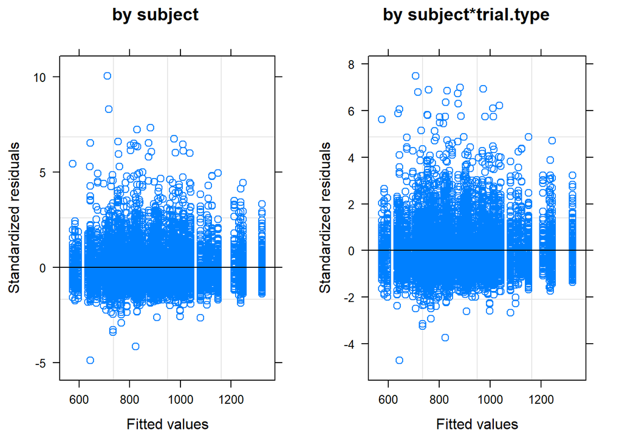

```r
grid.arrange(
  plot(fit1.het, main = "by subject"),
  plot(fit1.het1, main = "by subject*trial.type"),
  ncol = 2
)
```

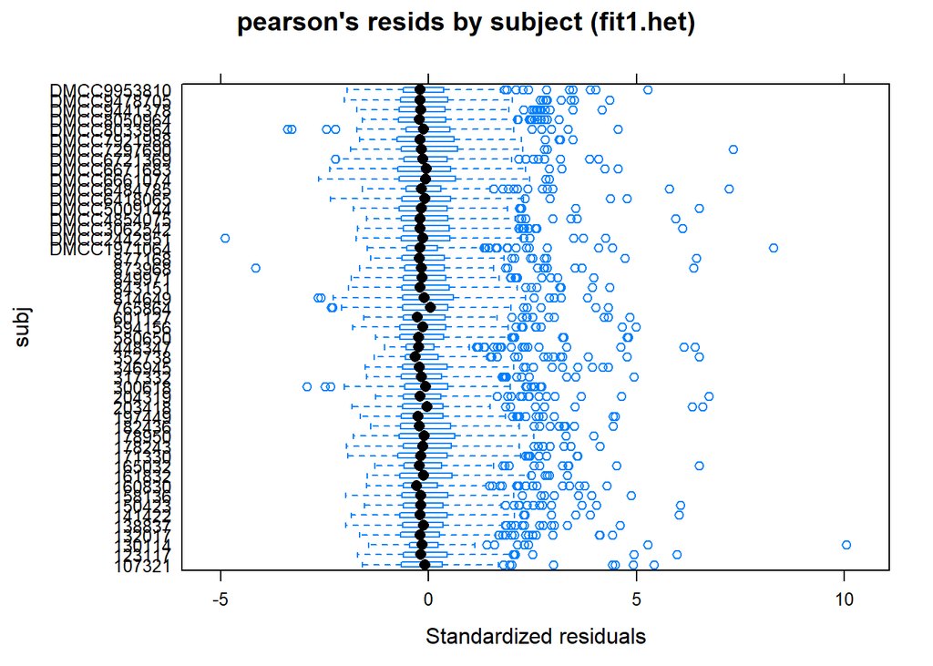

```r
plot(fit1.het, subj ~ resid(., type = "p"), main = "pearson's resids by subject (fit1.het)")
```

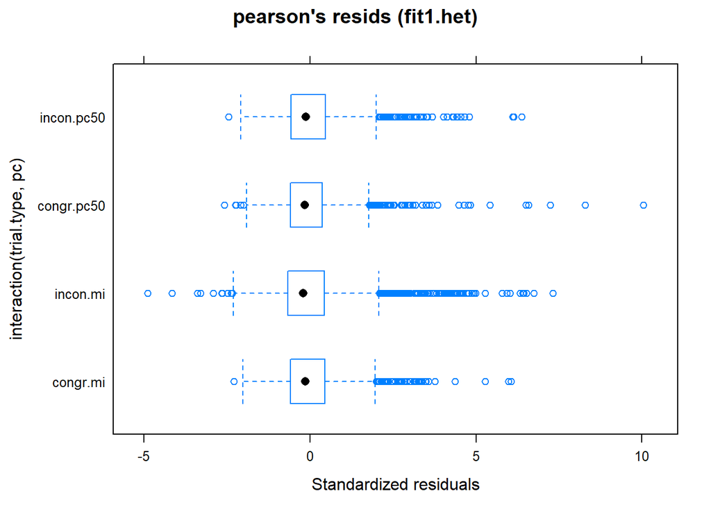

```r
plot(fit1.het, interaction(trial.type, pc) ~ resid(., type = "p"), main = "pearson's resids (fit1.het)")
```

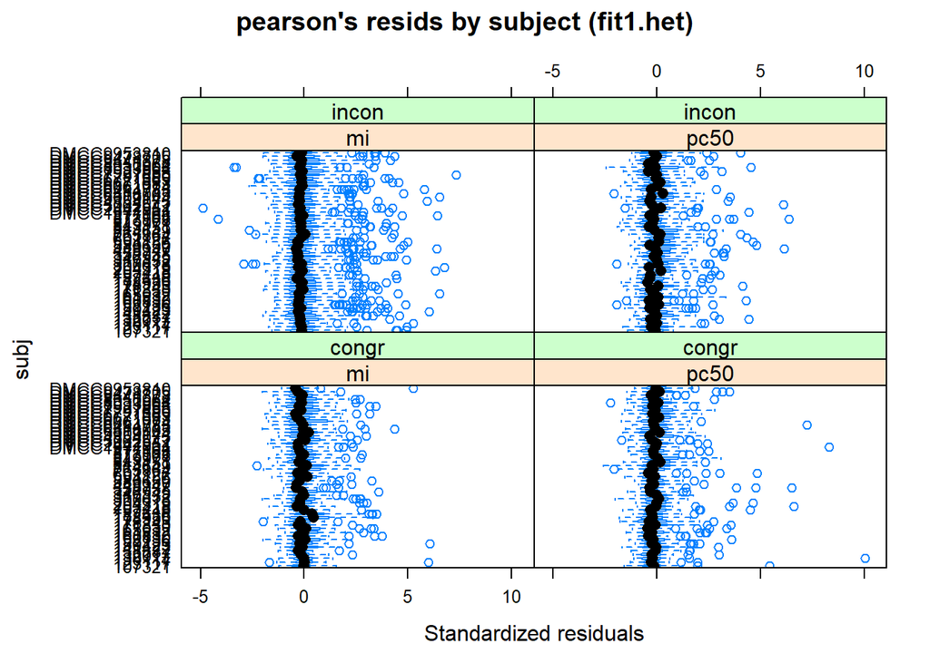

```r
plot(fit1.het, subj ~ resid(., type = "p") | pc * trial.type, main = "pearson's resids by subject (fit1.het)")
```

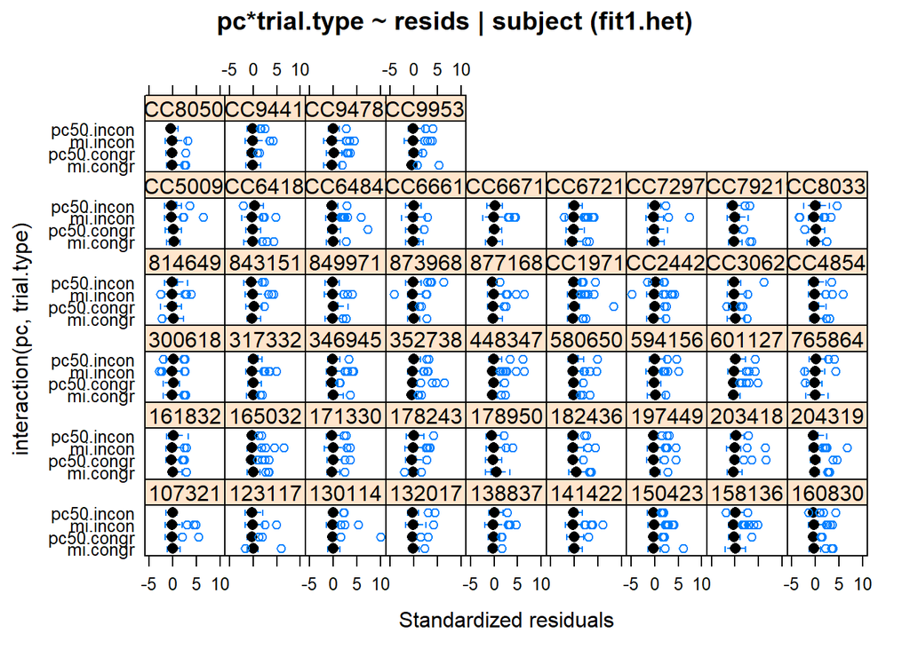

```r
## missing any key interactions?

plot(
  fit1.het,
  interaction(pc, trial.type) ~ resid(., type = "p") | subj,
  main = "pc*trial.type ~ resids | subject (fit1.het)"
  )
```

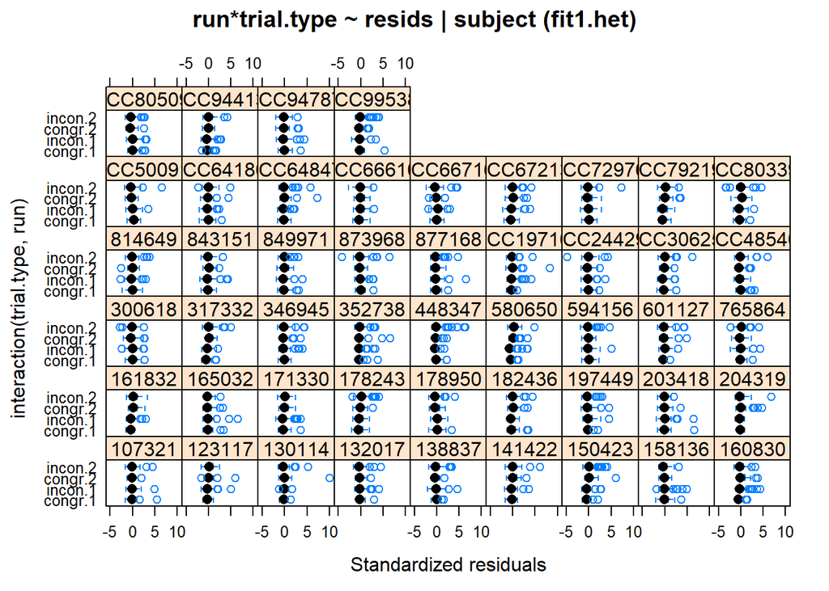

```r
plot(
  fit1.het,
  interaction(trial.type, run) ~ resid(., type = "p") | subj,
  main = "run*trial.type ~ resids | subject (fit1.het)"
  )
```

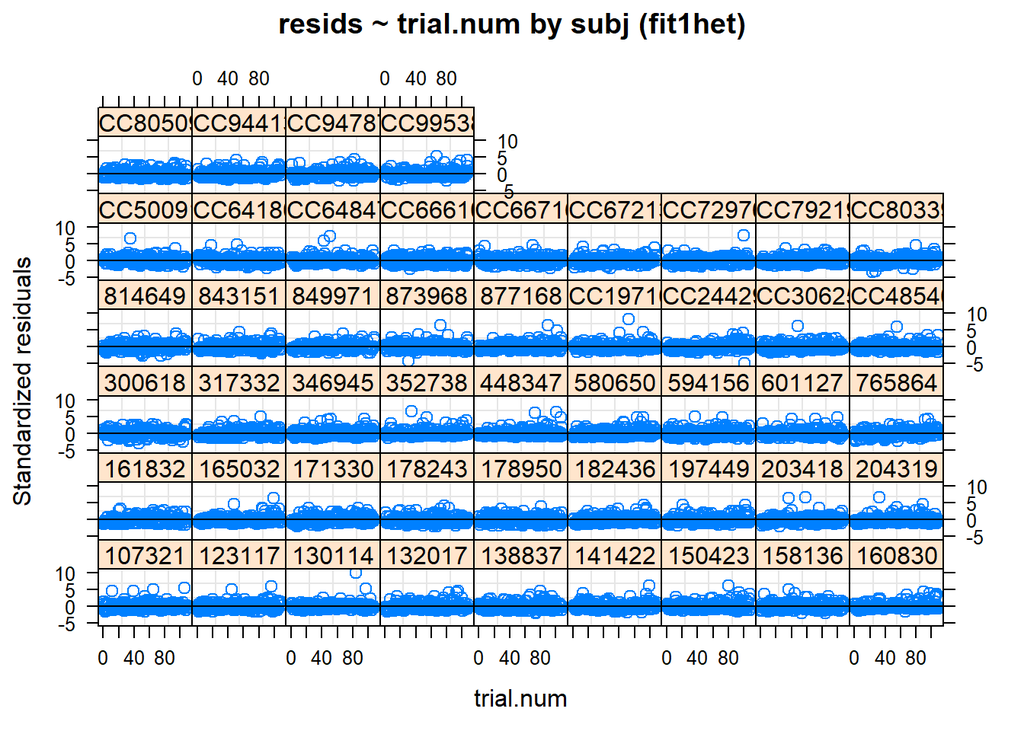

```r
plot(fit1.het, resid(., type = "p") ~ trial.num | subj, abline = 0, main = "resids ~ trial.num by subj (fit1het)")
```

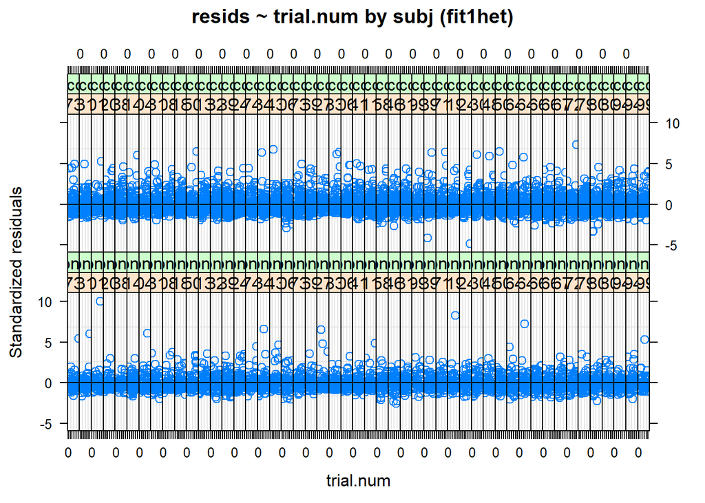

```r
plot(
  fit1.het,
  resid(., type = "p") ~ trial.num | subj * trial.type, abline = 0,
  main = "resids ~ trial.num by subj (fit1het)"
  )
```

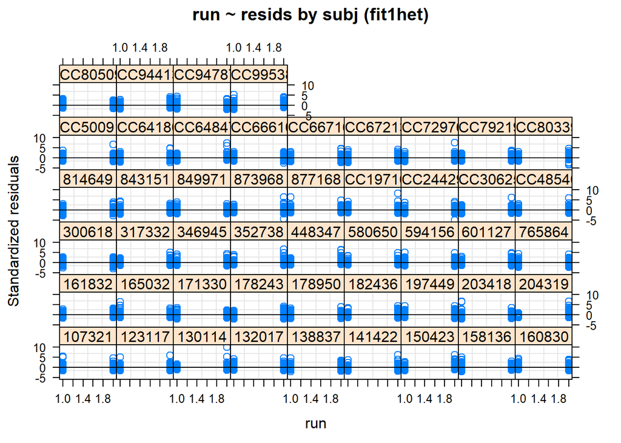

```r
plot(fit1.het, resid(., type = "p") ~ run | subj, abline = 0, main = "run ~ resids by subj (fit1het)")
```

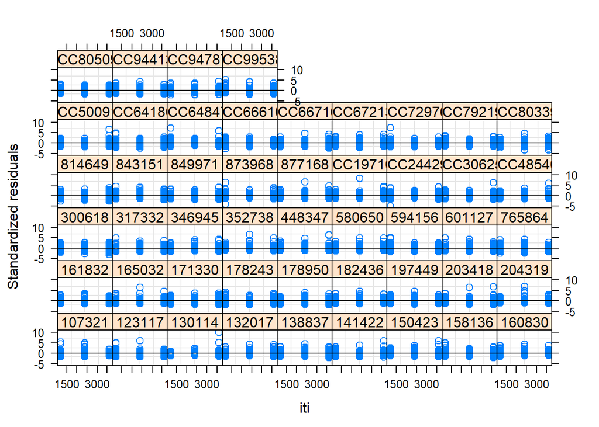

```r
plot(fit1.het, resid(., type = "p") ~ iti | subj, abline = 0)
```

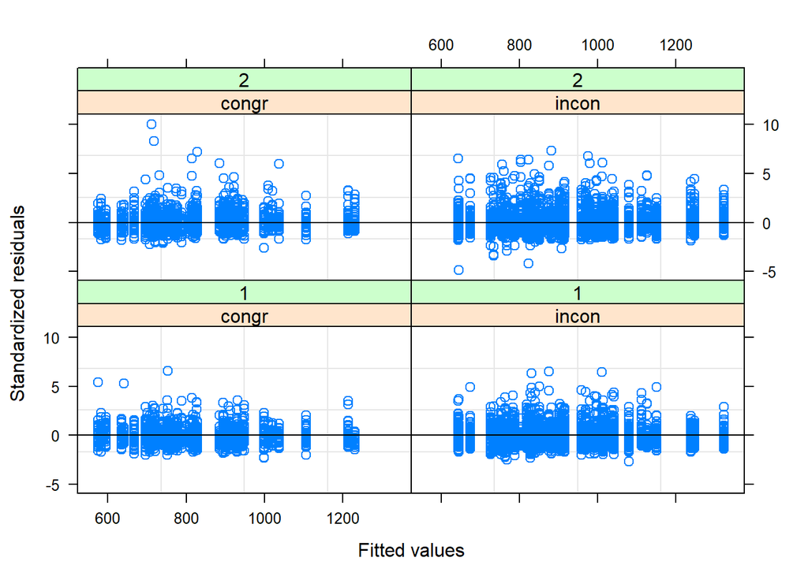

```r
## by trialtype

plot(fit1.het, resid(., type = "p") ~ fitted(.) | trial.type * as.factor(run), abline = 0)
```

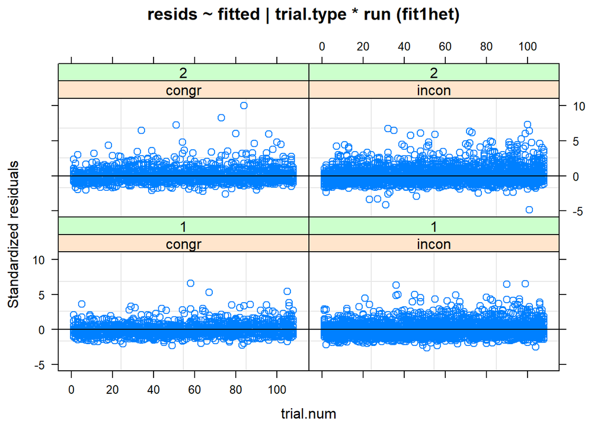

```r
plot(
  fit1.het,
  resid(., type = "p") ~ trial.num | trial.type * as.factor(run),
  abline = 0,
  main = "resids ~ fitted | trial.type * run (fit1het)"
  )
```

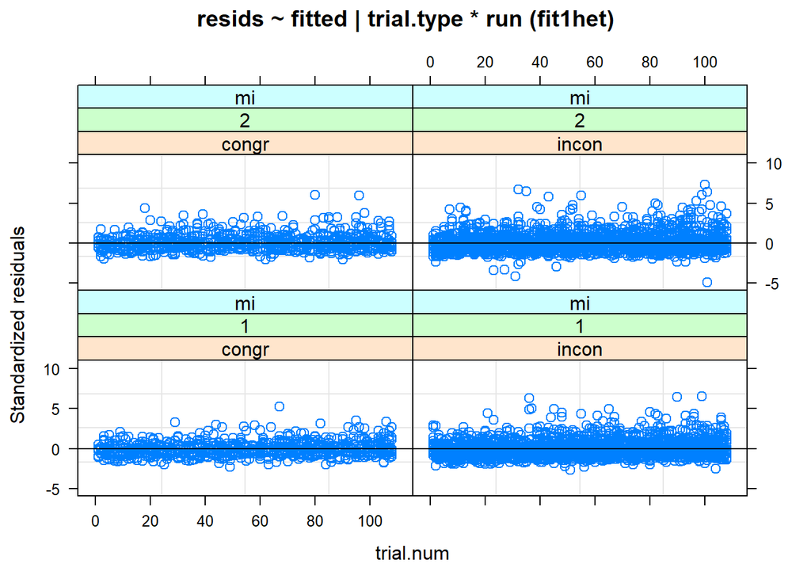

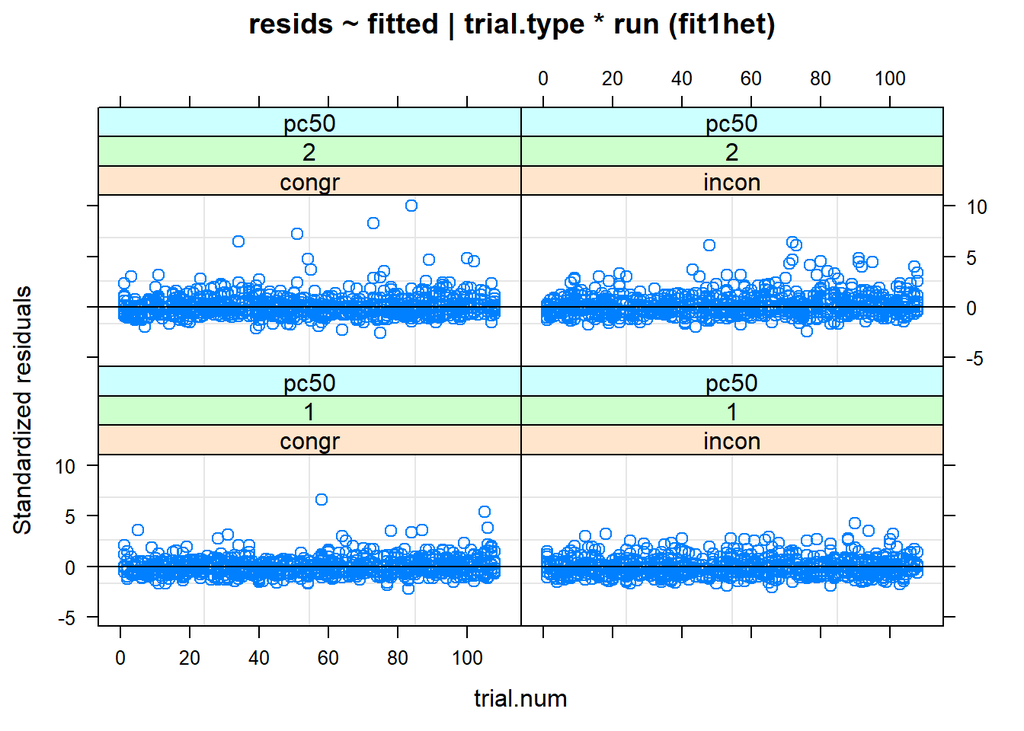

```r
plot(
  fit1.het,
  resid(., type = "p") ~ trial.num | trial.type * as.factor(run) * pc,
  abline = 0,
  main = "resids ~ fitted | trial.type * run (fit1het)"
  )
```

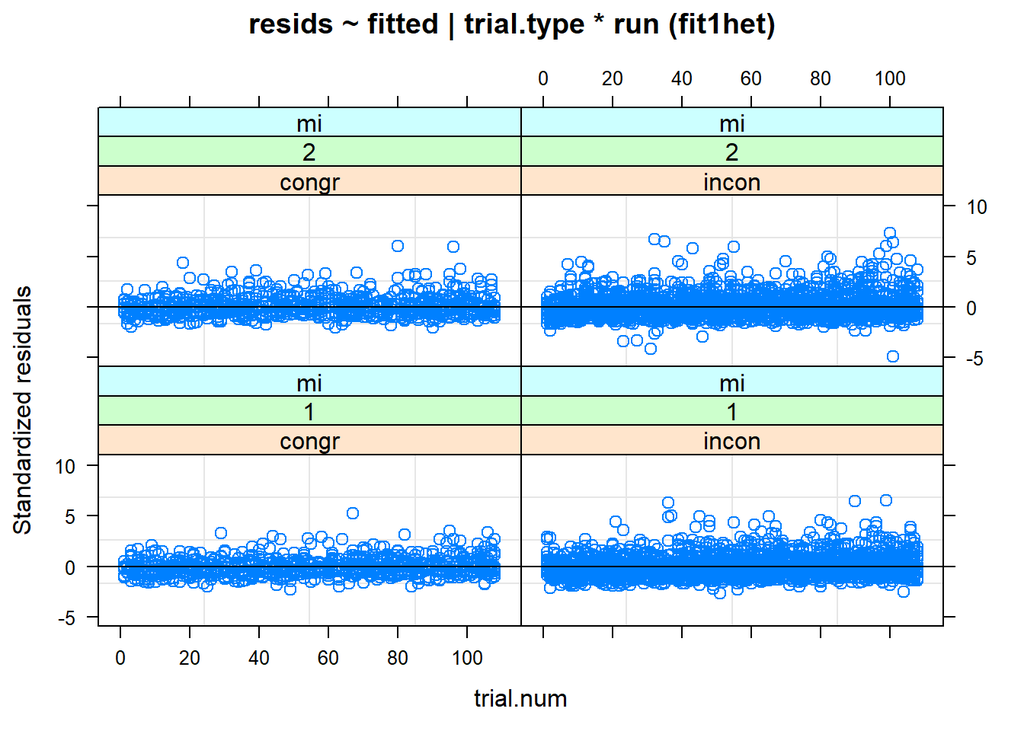

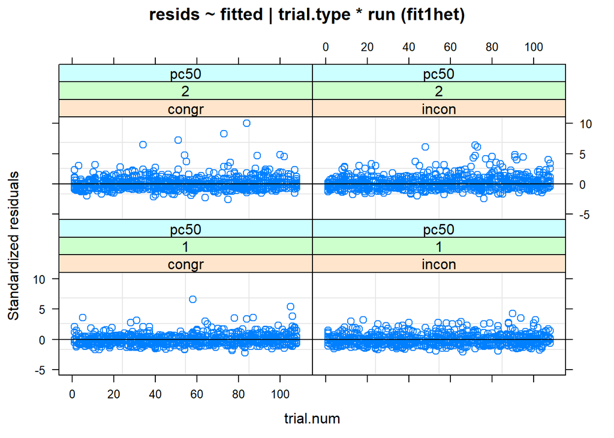

```r
plot(
  fit1.het,
  resid(., type = "p") ~ trial.num | trial.type * as.factor(run) * pc,
  abline = 0,
  main = "resids ~ fitted | trial.type * run (fit1het)"
  )
```

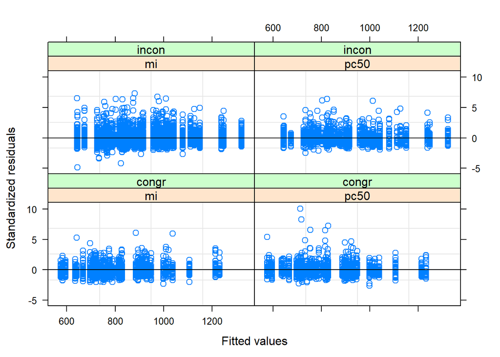

```r
## by item

plot(fit1.het, resid(., type = "p") ~ fitted(.) | pc * trial.type, abline = 0)
```

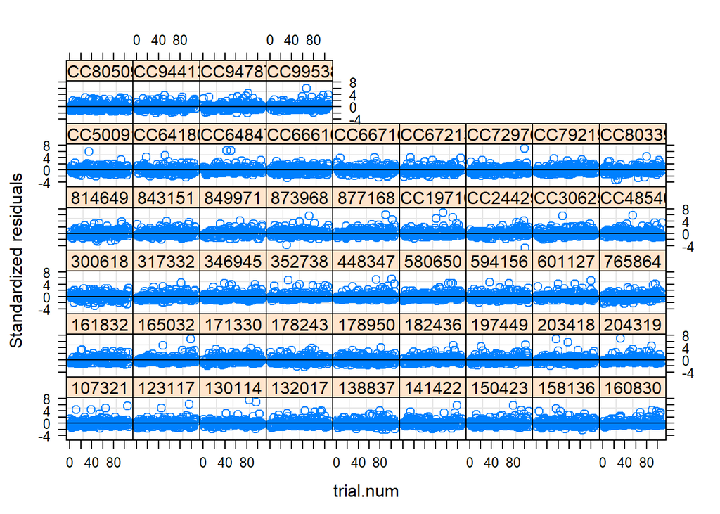

```r
plot(fit1.het1, resid(., type = "p") ~ trial.num | subj, abline = 0)
```

```r
head(stroop.pro.rt)
```

```
## # A tibble: 6 x 35
## # Groups:   subj, session, run [1]
##   session task    run subj  name  word  trial.type pc    color   iti
##   <chr>   <chr> <int> <chr> <chr> <chr> <chr>      <chr> <chr> <int>
## 1 pro     stp       1 1073~ pro_~ WHITE incon      mi    purp~  2400
## 2 pro     stp       1 1073~ pro_~ WHITE incon      mi    purp~  1200
## 3 pro     stp       1 1073~ pro_~ BLACK incon      pc50  green  3600
## 4 pro     stp       1 1073~ pro_~ BLUE  congr      mi    blue   2400
## 5 pro     stp       1 1073~ pro_~ YELL~ incon      pc50  pink   3600
## 6 pro     stp       1 1073~ pro_~ BLUE  incon      mi    white  2400
## # ... with 25 more variables: time.target.onset.abs <int>,
## #   time.scan.start <int>, trial.num <int>, listener1 <chr>, listener2 <chr>,
## #   correctcolor <chr>, response.final <chr>, acc.final <chr>, rt <dbl>,
## #   item <chr>, time.target.onset <dbl>, time.rt.abs <dbl>, time.rt <dbl>,
## #   acc <int>, time.block1.on <dbl>, time.block2.on <dbl>,
## #   time.block3.on <dbl>, time.block1.off <dbl>, time.block2.off <dbl>,
## #   time.block3.off <dbl>, is.analysis.group <lgl>, error <dbl>,
## #   post.error <dbl>, n1.trial.type <chr>, n2.trial.type <chr>
```

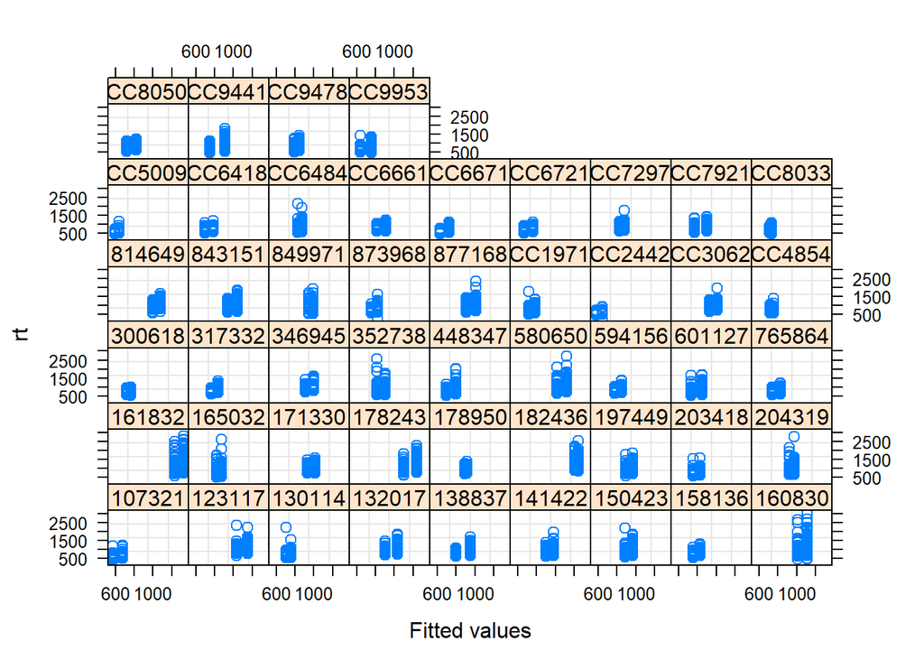

```r
plot(fit1.het1, rt ~ fitted(.) | subj)
```

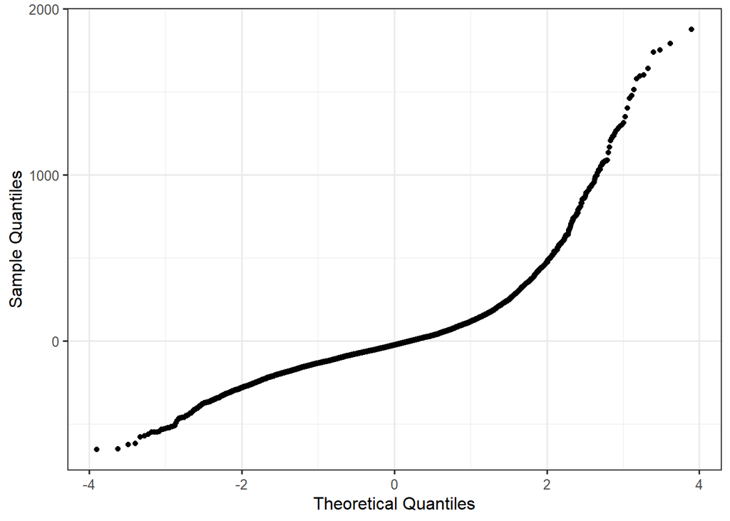

```r
ggplot_qqnorm(resid(fit1.het))
```

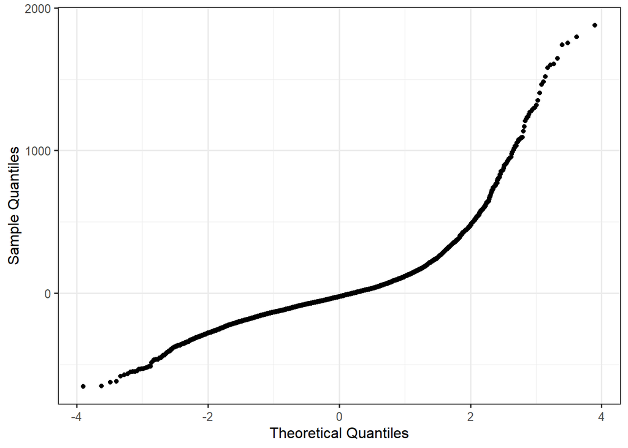

```r
ggplot_qqnorm(resid(fit1.het1))
```

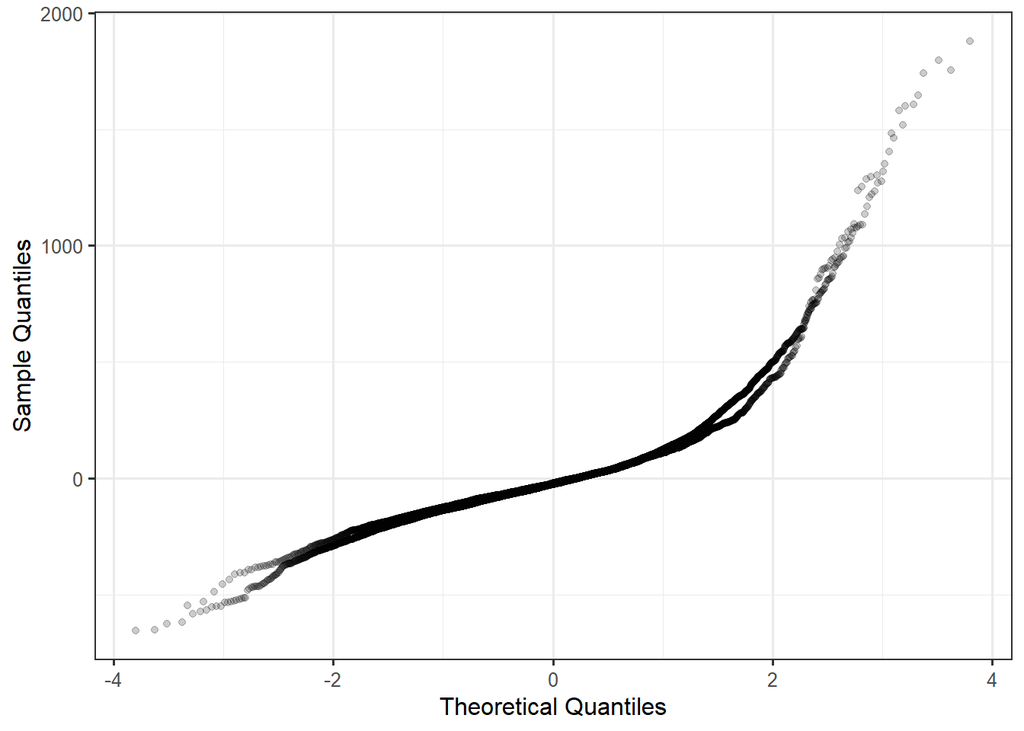

```r
group_qqnorm(
  resid(fit1.het1), stroop.pro.rt$trial.type, alpha_point = 0.2,
  fill = stroop.pro.rt$trial.type
  )
```

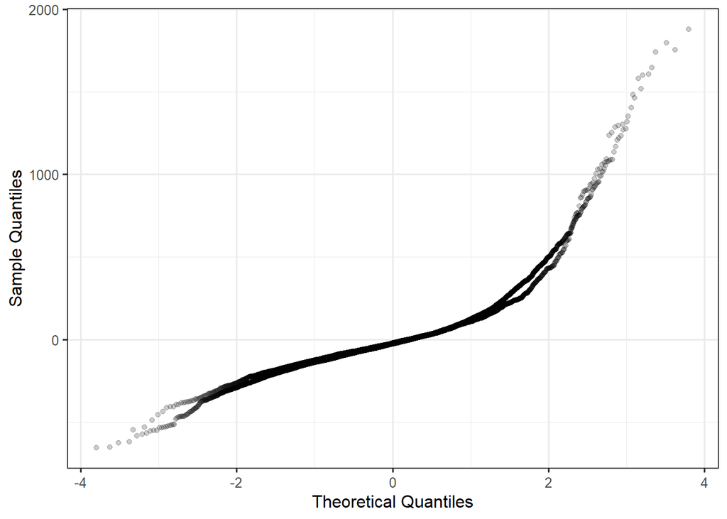

```r
group_qqnorm(resid(fit1.het1), stroop.pro.rt$trial.type, alpha_point = 0.2)  ## by subj
```

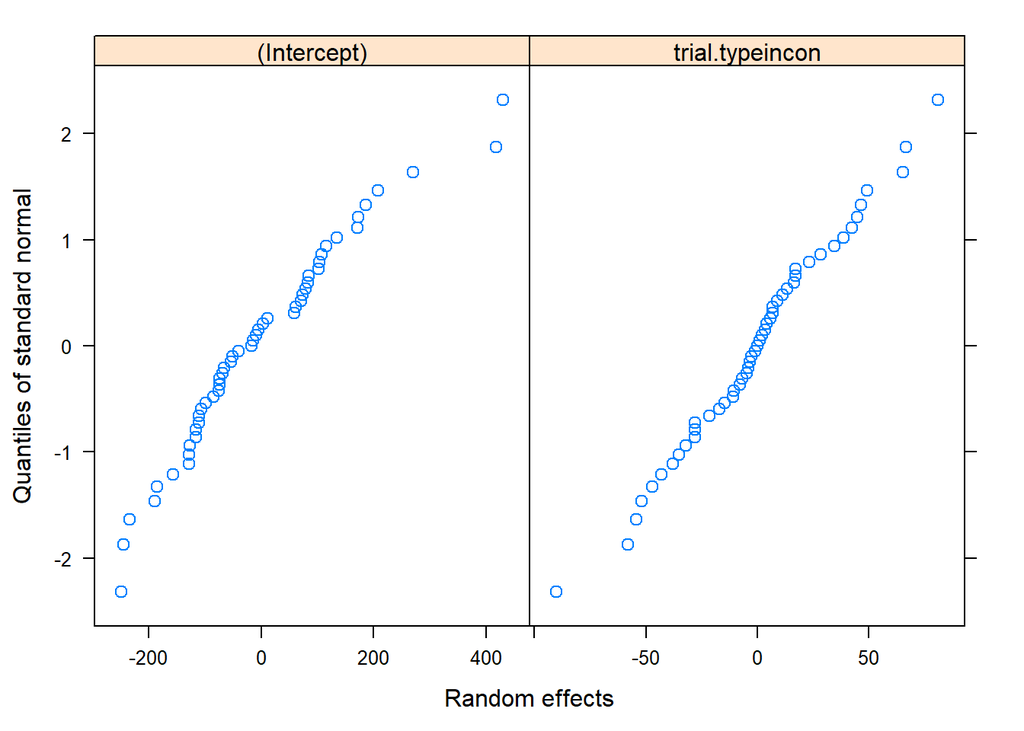

```r
qqnorm(fit1.hom, ~ ranef(., level = 1))
```

```r
fit1.het.pc <- lme(
  rt ~ trial.type * pc, stroop.pro.rt, ~ trial.type | subj,
  weights = varIdent(form = ∼ 1 | subj),
  control = cl1
  )
summary(fit1.het.pc)
```

```
## Linear mixed-effects model fit by REML
##  Data: stroop.pro.rt
##      AIC    BIC logLik
##   132174 132579 -66031
##
## Random effects:
##  Formula: ~trial.type | subj
##  Structure: General positive-definite, Log-Cholesky parametrization
##                 StdDev Corr
## (Intercept)     150.06 (Intr)
## trial.typeincon  36.01 0.011
## Residual        111.27
##
## Variance function:
##  Structure: Different standard deviations per stratum
##  Formula: ~1 | subj
##  Parameter estimates:
##      107321      123117      130114      132017      138837      141422
##      1.0000      1.9585      1.3549      1.6335      1.4147      1.4819
##      150423      158136      160830      161832      165032      171330
##      1.9228      0.8895      3.9317      3.9512      2.4012      1.3589
##      178243      178950      182436      197449      203418      204319
##      2.2441      1.0425      2.5625      1.7264      1.0473      2.3865
##      300618      317332      346945      352738      448347      580650
##      0.7583      0.9184      1.2468      2.4178      1.7047      2.9988
##      594156      601127      765864      814649      843151      849971
##      0.9046      1.6870      0.8006      1.3619      1.7230      2.1483
##      873968      877168 DMCC1971064 DMCC2442951 DMCC3062542 DMCC4854075
##      1.1227      1.8882      1.1564      0.6269      1.4028      0.9728
## DMCC5009144 DMCC6418065 DMCC6484785 DMCC6661074 DMCC6671683 DMCC6721369
##      0.7276      0.7665      1.6376      1.0157      0.7458      0.7979
## DMCC7297690 DMCC7921988 DMCC8033964 DMCC8050964 DMCC9441378 DMCC9478705
##      1.1140      1.5455      0.7080      1.2236      1.9513      1.2204
## DMCC9953810
##      1.3016
## Fixed effects: rt ~ trial.type * pc
##                        Value Std.Error    DF t-value p-value
## (Intercept)            826.1    21.749 10176   37.98  0.0000
## trial.typeincon         79.2     6.614 10176   11.97  0.0000
## pcpc50                   1.1     4.393 10176    0.26  0.7986
## trial.typeincon:pcpc50   9.8     5.681 10176    1.73  0.0842
##  Correlation:
##                        (Intr) trl.ty pcpc50
## trial.typeincon        -0.079
## pcpc50                 -0.100  0.330
## trial.typeincon:pcpc50  0.077 -0.340 -0.773
##
## Standardized Within-Group Residuals:
##     Min      Q1     Med      Q3     Max
## -4.8734 -0.6262 -0.1745  0.4242 10.0478
##
## Number of Observations: 10228
## Number of Groups: 49
```

```r
fit1.het.pc1 <- lme(
  rt ~ trial.type * pc, stroop.pro.rt, ~ trial.type * pc | subj,
  weights = varIdent(form = ∼ 1 | subj),
  control = cl1
  )
summary(fit1.het.pc1)
```

```
## Linear mixed-effects model fit by REML
##  Data: stroop.pro.rt
##      AIC    BIC logLik
##   132169 132625 -66022
##
## Random effects:
##  Formula: ~trial.type * pc | subj
##  Structure: General positive-definite, Log-Cholesky parametrization
##                        StdDev Corr
## (Intercept)            160.07 (Intr) trl.ty pcpc50
## trial.typeincon         40.26 -0.197
## pcpc50                  22.92 -0.875  0.395
## trial.typeincon:pcpc50  13.42  0.753 -0.742 -0.686
## Residual               111.19
##
## Variance function:
##  Structure: Different standard deviations per stratum
##  Formula: ~1 | subj
##  Parameter estimates:
##      107321      123117      130114      132017      138837      141422
##      1.0000      1.9515      1.3559      1.6295      1.4152      1.4846
##      150423      158136      160830      161832      165032      171330
##      1.9202      0.8910      3.9205      3.9569      2.3940      1.3621
##      178243      178950      182436      197449      203418      204319
##      2.2551      1.0290      2.5299      1.7267      1.0415      2.3926
##      300618      317332      346945      352738      448347      580650
##      0.7589      0.9189      1.2415      2.4186      1.7020      3.0028
##      594156      601127      765864      814649      843151      849971
##      0.9047      1.6849      0.8024      1.3615      1.7257      2.1564
##      873968      877168 DMCC1971064 DMCC2442951 DMCC3062542 DMCC4854075
##      1.1234      1.8805      1.1572      0.6234      1.3946      0.9750
## DMCC5009144 DMCC6418065 DMCC6484785 DMCC6661074 DMCC6671683 DMCC6721369
##      0.7298      0.7688      1.6432      1.0142      0.7418      0.7980
## DMCC7297690 DMCC7921988 DMCC8033964 DMCC8050964 DMCC9441378 DMCC9478705
##      1.1151      1.5419      0.7053      1.2144      1.9492      1.2218
## DMCC9953810
##      1.3005
## Fixed effects: rt ~ trial.type * pc
##                        Value Std.Error    DF t-value p-value
## (Intercept)            830.7    23.183 10176   35.83  0.0000
## trial.typeincon         76.2     7.174 10176   10.62  0.0000
## pcpc50                  -8.5     5.586 10176   -1.52  0.1293
## trial.typeincon:pcpc50  13.4     6.021 10176    2.22  0.0266
##  Correlation:
##                        (Intr) trl.ty pcpc50
## trial.typeincon        -0.237
## pcpc50                 -0.591  0.455
## trial.typeincon:pcpc50  0.311 -0.515 -0.699
##
## Standardized Within-Group Residuals:
##     Min      Q1     Med      Q3     Max
## -4.8560 -0.6270 -0.1741  0.4232 10.0401
##
## Number of Observations: 10228
## Number of Groups: 49
```

```r
cbind(
  anova(fit1.het.pc, fit1.het.pc1),
  BICweight = icweight(anova(fit1.het.pc, fit1.het.pc1), "BIC"),
  AICweight = icweight(anova(fit1.het.pc, fit1.het.pc1), "AIC")
  ) %>%
  kable(digits = 2)
```

|  | call | Model | df | AIC | BIC | logLik | Test | L.Ratio | p-value | BICweight | AICweight |
| --- | --- | --- | --- | --- | --- | --- | --- | --- | --- | --- | --- |
| fit1.het.pc | lme.formula(fixed = rt ~ trial.type * pc, data = stroop.pro.rt, random = ~trial.type \| subj, weights = varIdent(form = ~1 \| subj), control = cl1) | 1 | 56 | 132174 | 132579 | -66031 |  | NA | NA | 1 | 0.09 |
| fit1.het.pc1 | lme.formula(fixed = rt ~ trial.type * pc, data = stroop.pro.rt, random = ~trial.type * pc \| subj, weights = varIdent(form = ~1 \| subj), control = cl1) | 2 | 63 | 132169 | 132625 | -66022 | 1 vs 2 | 18.73 | 0.01 | 0 | 0.91 |

### assessing shrinkage

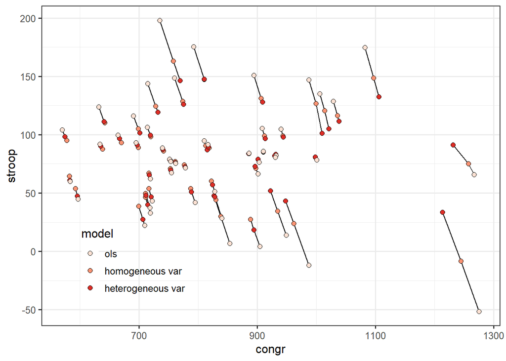

```r
l <- split(stroop.pro.rt, stroop.pro.rt$subj)
f <- lapply(l, function(x) coef(lm(rt ~ trial.type, x)))
ols <- as.data.frame(do.call(rbind, f))

coefs <- rbind(
  cbind(tibble::rownames_to_column(coef(fit1.hom), "subj"), model = "hom"),
  cbind(tibble::rownames_to_column(coef(fit1.het), "subj"), model = "het"),
  cbind(tibble::rownames_to_column(ols, "subj"), model = "ols")
)

coefs %<>% rename(congr = "(Intercept)", stroop = trial.typeincon)
coefs$model <- relevel(coefs$model, "ols")

coefs %>%
  ggplot(aes(congr, stroop, fill = model)) +
  geom_line(aes(group = subj)) +
  geom_point(shape = 21, color = "black", size = 2) +
  scale_fill_manual(
    values = c(ols = "#fee0d2", hom = "#fc9272", het = "#de2d26"),
    labels = c(ols = "ols", hom = "homogeneous var", het = "heterogeneous var")
    ) +
  theme(legend.position = c(0.2, 0.2), legend.background = element_blank())
```

- Slopes (stroop effects) are shrunk more than intercepts (congruent RT). This was expected.
- Also seems the heterogeneous variance model increased the shrinkage relative to the homogenous model. And that this shrinkage was generally linear or proportional across subjects relative to the ols $\rightarrow$ homogeneous variance model.

### assessing split-half-consistency

Here I assess the split-half consistency, or cross-run correlation, via the heterogeneous model. First I fit a model containing an interaction between trial.type and run, for each subject:

```r
fit1.het.run <- lme(
  rt ~ trial.type * run, stroop.pro.rt, ~ trial.type * run | subj,
  weights = varIdent(form = ∼ 1 | subj),
  control = cl1,
  method = "REML"
  )

summary(fit1.het.run)
```

```
## Linear mixed-effects model fit by REML
##  Data: stroop.pro.rt
##      AIC    BIC logLik
##   132048 132503 -65961
##
## Random effects:
##  Formula: ~trial.type * run | subj
##  Structure: General positive-definite, Log-Cholesky parametrization
##                     StdDev Corr
## (Intercept)         112.85 (Intr) trl.ty run
## trial.typeincon      28.66  0.381
## run                  50.31  0.231  0.130
## trial.typeincon:run  12.44 -0.760  0.178  0.219
## Residual            111.07
##
## Variance function:
##  Structure: Different standard deviations per stratum
##  Formula: ~1 | subj
##  Parameter estimates:
##      107321      123117      130114      132017      138837      141422
##      1.0000      1.9381      1.3573      1.6372      1.4230      1.4624
##      150423      158136      160830      161832      165032      171330
##      1.8087      0.8905      3.9077      3.8168      2.4022      1.3441
##      178243      178950      182436      197449      203418      204319
##      2.1934      1.0097      2.5294      1.7219      1.0505      2.3425
##      300618      317332      346945      352738      448347      580650
##      0.7628      0.8947      1.2492      2.3977      1.6750      2.7832
##      594156      601127      765864      814649      843151      849971
##      0.9098      1.6976      0.8068      1.3655      1.7214      2.1509
##      873968      877168 DMCC1971064 DMCC2442951 DMCC3062542 DMCC4854075
##      1.1295      1.8889      1.1623      0.6296      1.3784      0.9757
## DMCC5009144 DMCC6418065 DMCC6484785 DMCC6661074 DMCC6671683 DMCC6721369
##      0.7096      0.7660      1.6177      1.0182      0.7454      0.7832
## DMCC7297690 DMCC7921988 DMCC8033964 DMCC8050964 DMCC9441378 DMCC9478705
##      1.1174      1.5073      0.6953      1.1861      1.9152      1.2194
## DMCC9953810
##      1.3043
## Fixed effects: rt ~ trial.type * run
##                     Value Std.Error    DF t-value p-value
## (Intercept)         786.1    17.821 10176   44.11  0.0000
## trial.typeincon      78.0     9.504 10176    8.20  0.0000
## run                  27.0     8.613 10176    3.13  0.0017
## trial.typeincon:run   2.8     5.665 10176    0.49  0.6246
##  Correlation:
##                     (Intr) trl.ty run
## trial.typeincon     -0.131
## run                 -0.042  0.379
## trial.typeincon:run  0.049 -0.763 -0.319
##
## Standardized Within-Group Residuals:
##     Min      Q1     Med      Q3     Max
## -5.0102 -0.6235 -0.1676  0.4281  9.9937
##
## Number of Observations: 10228
## Number of Groups: 49
```

Within this model, there are two estimates available of the consistency or correlation between split halves.

1. One is *conditional* on the observed data (y). This is obtained by extracting the “conditional modes” of the estimate, and estimating pearson’s correlation between them. These conditional modes are the most likely value of $b$, given (conditioned on) y; i.e., the random slopes for each subject.
2. the other method gives a correlation statistic that is not conditioned on the data, but rather is marginalized across all possible values of the data (“unconditional”). What this means exactly I don’t know. But see [here](https://stats.stackexchange.com/questions/153253/random-slope-and-intercept-correlation-not-consistent-in-output-vs-manual-calcu) or [here](https://stat.ethz.ch/pipermail/r-sig-mixed-models/2009q1/001763.html) for further reading.

Note that because of the way I coded the `trial.type` and `run` variables in my model, I will need to do some algebra to get the stroop effects and (co)variance thereof in each run.

```r
m <- rbind(c(0, 1, 0, 0), c(0, 1, 0, 1))  ## a contrast matrix that gives us what we want

## conditional covariances

u <- as.matrix(coef(fit1.het.run)) %*% t(m)
cov(u)
```

```
##       [,1]  [,2]
## [1,] 612.5 640.9
## [2,] 640.9 791.0
```

```r
(r.conditional <- cor(u)[1, 2])  ## correlation of conditional modes
```

```
## [1] 0.9208
```

```r
## unconditional / marginal covariances

tau <- getVarCov(fit1.het.run)
(tau <- m %*% tau %*% t(m))
```

```
##       [,1]   [,2]
## [1,] 821.6  885.1
## [2,] 885.1 1103.4
```

```r
r.marginal <- cov2cor(tau)[1, 2]
```

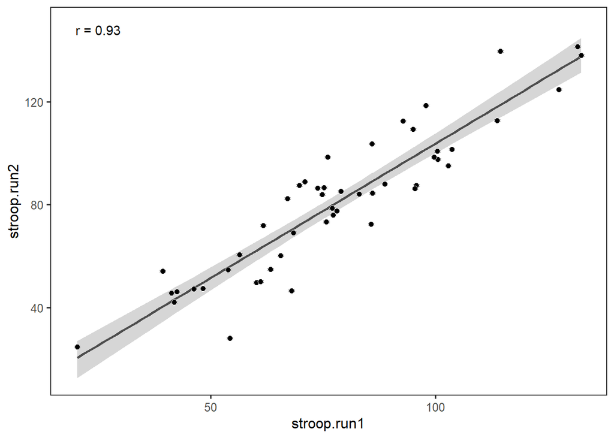

```r
u <- as.data.frame(u)

names(u) <- c("stroop.run1", "stroop.run2")

u %>%
  ggplot(aes(stroop.run1, stroop.run2)) +
  stat_boot_ci(n = 1E4, alpha = 0.2) +
  geom_smooth(method = "lm", se = FALSE, color = "grey30") +
  geom_point(shape = 21, color = "white", fill = "black", size = 2) +
  annotate(geom = "text", label = paste0("r = ", round(r.marginal, 2)), y = 150, x = 20, vjust = 1, hjust = 0) +
  theme(panel.grid = element_blank())
```

```r
cl3 <- lmeControl(maxIter = 1e5, msMaxIter = 1e5, niterEM = 1e5, msMaxEval = 1e5, apVar = FALSE)

fit1.het.reml <- lme(
  rt ~ trial.type, stroop.pro.rt, ~ trial.type | subj,
  weights = varIdent(form = ∼ 1 | subj),
  control = cl1,
  method = "REML"
  )
summary(fit1.het.reml)
```

```
## Linear mixed-effects model fit by REML
##  Data: stroop.pro.rt
##      AIC    BIC logLik
##   132188 132579 -66040
##
## Random effects:
##  Formula: ~trial.type | subj
##  Structure: General positive-definite, Log-Cholesky parametrization
##                 StdDev Corr
## (Intercept)     150.07 (Intr)
## trial.typeincon  36.03 0.01
## Residual        110.88
##
## Variance function:
##  Structure: Different standard deviations per stratum
##  Formula: ~1 | subj
##  Parameter estimates:
##      107321      123117      130114      132017      138837      141422
##      1.0000      1.9626      1.3614      1.6362      1.4220      1.4877
##      150423      158136      160830      161832      165032      171330
##      1.9267      0.8944      3.9414      3.9666      2.4072      1.3604
##      178243      178950      182436      197449      203418      204319
##      2.2549      1.0427      2.5699      1.7306      1.0552      2.3967
##      300618      317332      346945      352738      448347      580650
##      0.7632      0.9239      1.2489      2.4306      1.7155      3.0107
##      594156      601127      765864      814649      843151      849971
##      0.9119      1.6979      0.8076      1.3682      1.7254      2.1531
##      873968      877168 DMCC1971064 DMCC2442951 DMCC3062542 DMCC4854075
##      1.1294      1.8893      1.1620      0.6325      1.4060      0.9750
## DMCC5009144 DMCC6418065 DMCC6484785 DMCC6661074 DMCC6671683 DMCC6721369
##      0.7300      0.7728      1.6407      1.0177      0.7499      0.7989
## DMCC7297690 DMCC7921988 DMCC8033964 DMCC8050964 DMCC9441378 DMCC9478705
##      1.1163      1.5469      0.7151      1.2216      1.9547      1.2266
## DMCC9953810
##      1.3067
## Fixed effects: rt ~ trial.type
##                 Value Std.Error    DF t-value p-value
## (Intercept)     826.7    21.641 10178   38.20       0
## trial.typeincon  81.3     6.183 10178   13.15       0
##  Correlation:
##                 (Intr)
## trial.typeincon -0.049
##
## Standardized Within-Group Residuals:
##     Min      Q1     Med      Q3     Max
## -4.8867 -0.6275 -0.1756  0.4246 10.0388
##
## Number of Observations: 10228
## Number of Groups: 49
```

```r
fit1.het.reml.noapvar <- lme(
  rt ~ trial.type, stroop.pro.rt, ~ trial.type | subj,
  weights = varIdent(form = ∼ 1 | subj),
  control = cl3,
  method = "REML"
  )
summary(fit1.het.reml.noapvar)
```

```
## Linear mixed-effects model fit by REML
##  Data: stroop.pro.rt
##      AIC    BIC logLik
##   132188 132579 -66040
##
## Random effects:
##  Formula: ~trial.type | subj
##  Structure: General positive-definite, Log-Cholesky parametrization
##                 StdDev Corr
## (Intercept)     150.07 (Intr)
## trial.typeincon  36.03 0.01
## Residual        110.88
##
## Variance function:
##  Structure: Different standard deviations per stratum
##  Formula: ~1 | subj
##  Parameter estimates:
##      107321      123117      130114      132017      138837      141422
##      1.0000      1.9626      1.3614      1.6362      1.4220      1.4877
##      150423      158136      160830      161832      165032      171330
##      1.9267      0.8944      3.9414      3.9666      2.4072      1.3604
##      178243      178950      182436      197449      203418      204319
##      2.2549      1.0427      2.5699      1.7306      1.0552      2.3967
##      300618      317332      346945      352738      448347      580650
##      0.7632      0.9239      1.2489      2.4306      1.7155      3.0107
##      594156      601127      765864      814649      843151      849971
##      0.9119      1.6979      0.8076      1.3682      1.7254      2.1531
##      873968      877168 DMCC1971064 DMCC2442951 DMCC3062542 DMCC4854075
##      1.1294      1.8893      1.1620      0.6325      1.4060      0.9750
## DMCC5009144 DMCC6418065 DMCC6484785 DMCC6661074 DMCC6671683 DMCC6721369
##      0.7300      0.7728      1.6407      1.0177      0.7499      0.7989
## DMCC7297690 DMCC7921988 DMCC8033964 DMCC8050964 DMCC9441378 DMCC9478705
##      1.1163      1.5469      0.7151      1.2216      1.9547      1.2266
## DMCC9953810
##      1.3067
## Fixed effects: rt ~ trial.type
##                 Value Std.Error    DF t-value p-value
## (Intercept)     826.7    21.641 10178   38.20       0
## trial.typeincon  81.3     6.183 10178   13.15       0
##  Correlation:
##                 (Intr)
## trial.typeincon -0.049
##
## Standardized Within-Group Residuals:
##     Min      Q1     Med      Q3     Max
## -4.8867 -0.6275 -0.1756  0.4246 10.0388
##
## Number of Observations: 10228
## Number of Groups: 49
```